# Predicting CPI for Alcoholic Beverages and Tobacco with Time Series Regression

Muhammet Enes Üstün

02 05 2021

## Introduction

In this exercise, aim is to construct a time regression model for predicting a macroeconomic variable Consumer Price Index for Alcoholic Beverages and Tobacco using recent values of CPI, USD-TL Exchange Rate, Consumer Confidence Index, Interest Rate for Loan. Datas were gathered from [EVDS](https://evds2.tcmb.gov.tr/) System of Central Bank of Turkey.

Required packages are used. These will be help us for visualization and manipulation of data and statistical operations.

```r
library(ggplot2)
library(ggcorrplot)
library(fpp)
library(data.table)
library(GGally)
library(readxl)
library(forecast)
```

Gathered data from EVDS is read and time series data is obtained.

```r
data = read_excel("DATA_HW2.xlsx")
data = as.data.table(data)
data$Date = as.Date(data$Date)
```

Let’s graph the CPI for Alcoholic Beverages and Tobacco between 01.2012 and 03.2021

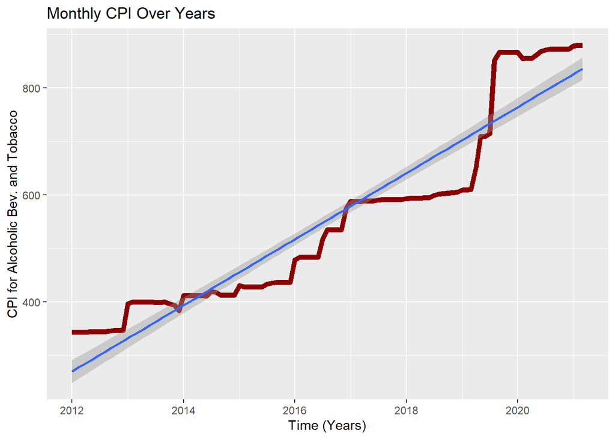

```r
ggplot(data, aes(x=Date, y=CPI_ALC_TOB)) + geom_line(size = 2, colour = "darkred") + labs(x = "Time (Years)", y = "CPI for Alcoholic Bev. and Tobacco",
title="Monthly CPI Over Years") + geom_smooth(method = "lm")
```

Let’s take logarithm because trend does not seem linear throughout time especially after 2019, and plot it.

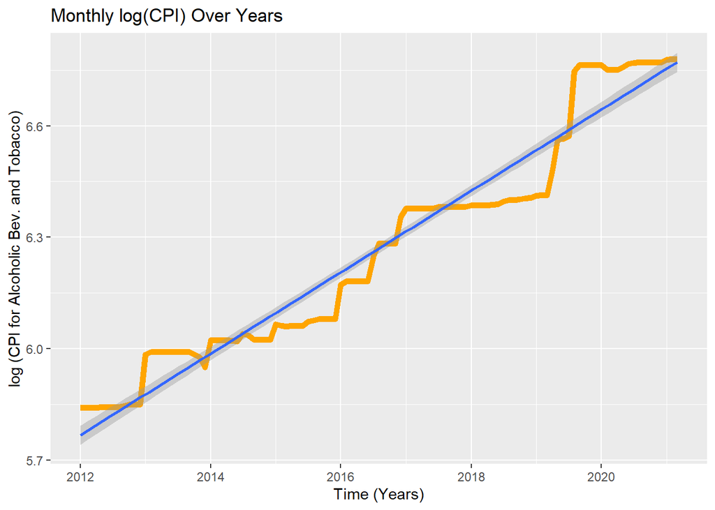

```r
data$CPI_ALC_TOB = log(data$CPI_ALC_TOB)

ggplot(data, aes(x=Date, y=CPI_ALC_TOB)) + geom_line(size = 2, colour = "orange") + labs(x = "Time (Years)", y = "log (CPI for Alcoholic Bev. and Tobacco)",
title="Monthly log(CPI) Over Years") + geom_smooth(method = "lm")
```

Let’s look at cross correlations between selected variables.

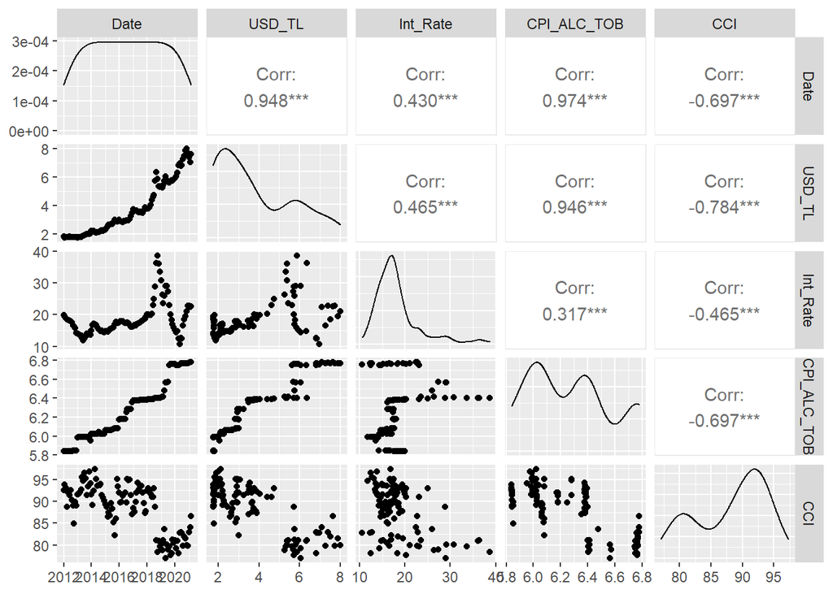

```r
ggpairs(data)
```

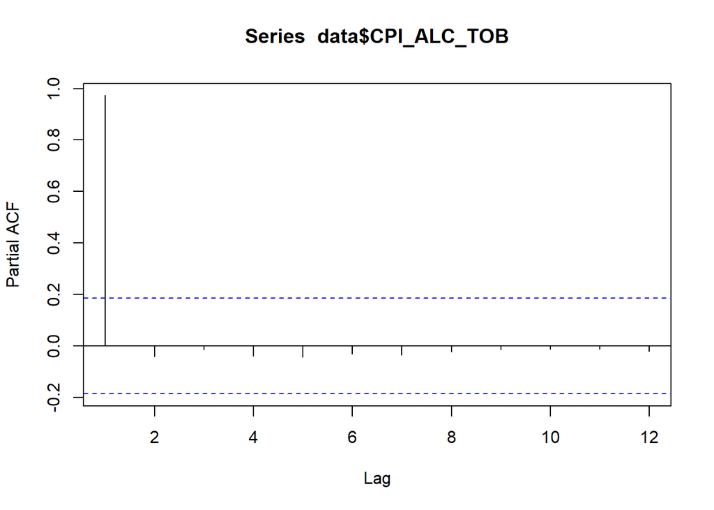

```r
pacf(data$CPI_ALC_TOB, lag.max = 12,  na.action = na.pass)
```

From the above table we can see that we have 1 period lag. Rest is not important, therefore we will use lag-1 in our analysis.

## Regression Models

Let’s start to build some models and investigate them. At each model, you will see summary of model, residuals analysis and plot of predicted values generated by that model vs actual values.

The huge shift in 2019 may be stem from exchange crisis happened in Turkey at 2018 Summer. That’s why we start to construct a model with USD_TL Exchange Rate.

```r
model1<- lm(CPI_ALC_TOB ~ USD_TL, data=data)
summary(model1)
```

```
##
## Call:
## lm(formula = CPI_ALC_TOB ~ USD_TL, data = data)
##
## Residuals:
##       Min        1Q    Median        3Q       Max
## -0.274173 -0.063895 -0.004848  0.085544  0.190458
##
## Coefficients:
##             Estimate Std. Error t value Pr(>|t|)
## (Intercept) 5.692149   0.021175   268.8   <2e-16 ***
## USD_TL      0.154387   0.005079    30.4   <2e-16 ***
## ---
## Signif. codes:  0 '***' 0.001 '**' 0.01 '*' 0.05 '.' 0.1 ' ' 1
##
## Residual standard error: 0.09847 on 109 degrees of freedom
## Multiple R-squared:  0.8945, Adjusted R-squared:  0.8935
## F-statistic:   924 on 1 and 109 DF,  p-value: < 2.2e-16
```

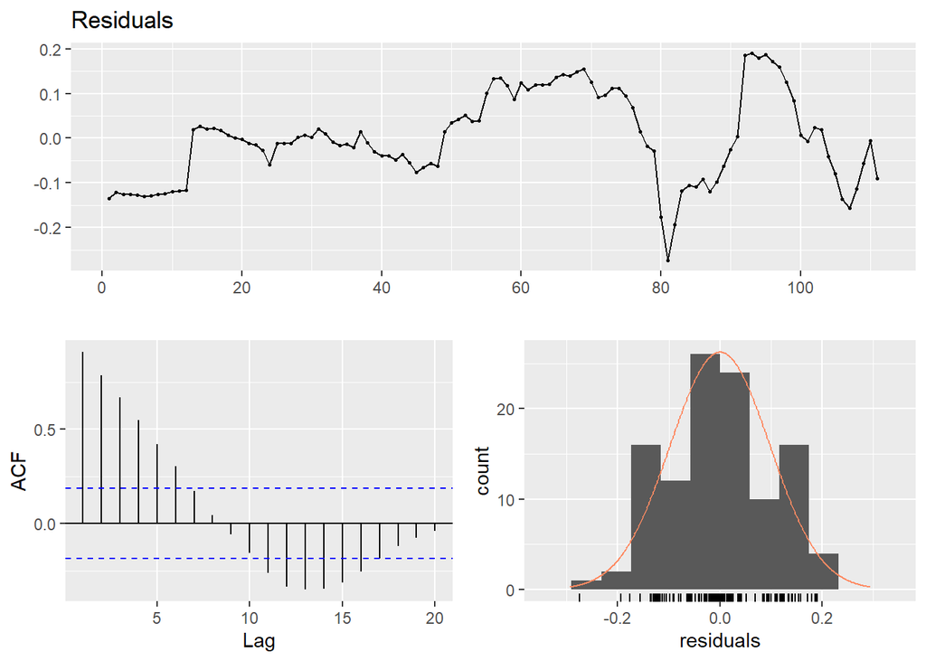

```
##
##  Breusch-Godfrey test for serial correlation of order up to 10
##
## data:  Residuals
## LM test = 95.258, df = 10, p-value = 4.826e-16
```

```r
checkresiduals(model1)
```

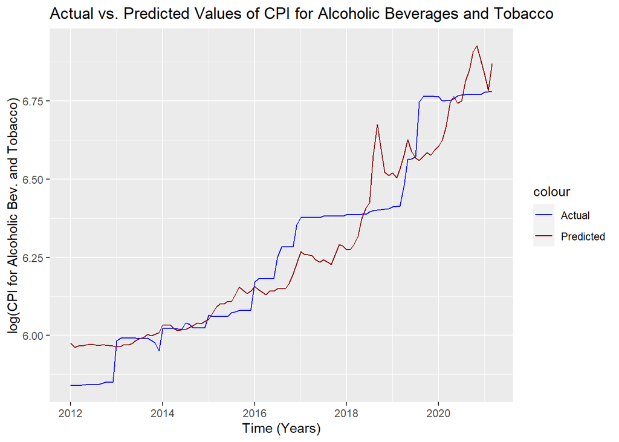

```r
data[,Fitted11:=predict(model1,data)]
cols <- c("Predicted" = "darkred", "Actual" = "blue")
ggplot(data ,aes(x=Date)) + geom_line(aes(y=CPI_ALC_TOB,color='Actual')) + geom_line(aes(y=Fitted11,color='Predicted')) + scale_color_manual(values = cols) +
labs(x = "Time (Years)", y = "log(CPI for Alcoholic Bev. and Tobacco)",
     title="Actual vs. Predicted Values of CPI for Alcoholic Beverages and Tobacco")
```

Not a bad consequence for first trial. Not surprisingly, USD_TL exchange rate is significant for our model. Let’s try other regressors to improve our model; decreasing Residual Standard Error, increasing R-Squared value and not autocorrelated, having mean approximately zero and constant variance.

```r
model2<- lm(CPI_ALC_TOB ~ USD_TL + CCI, data)
summary(model2)
```

```
##
## Call:
## lm(formula = CPI_ALC_TOB ~ USD_TL + CCI, data = data)
##
## Residuals:
##       Min        1Q    Median        3Q       Max
## -0.267326 -0.072092 -0.006821  0.071489  0.229148
##
## Coefficients:
##             Estimate Std. Error t value Pr(>|t|)
## (Intercept) 5.078134   0.262206  19.367   <2e-16 ***
## USD_TL      0.169132   0.008010  21.114   <2e-16 ***
## CCI         0.006325   0.002693   2.349   0.0206 *
## ---
## Signif. codes:  0 '***' 0.001 '**' 0.01 '*' 0.05 '.' 0.1 ' ' 1
##
## Residual standard error: 0.09649 on 108 degrees of freedom
## Multiple R-squared:  0.8996, Adjusted R-squared:  0.8978
## F-statistic: 483.9 on 2 and 108 DF,  p-value: < 2.2e-16
```

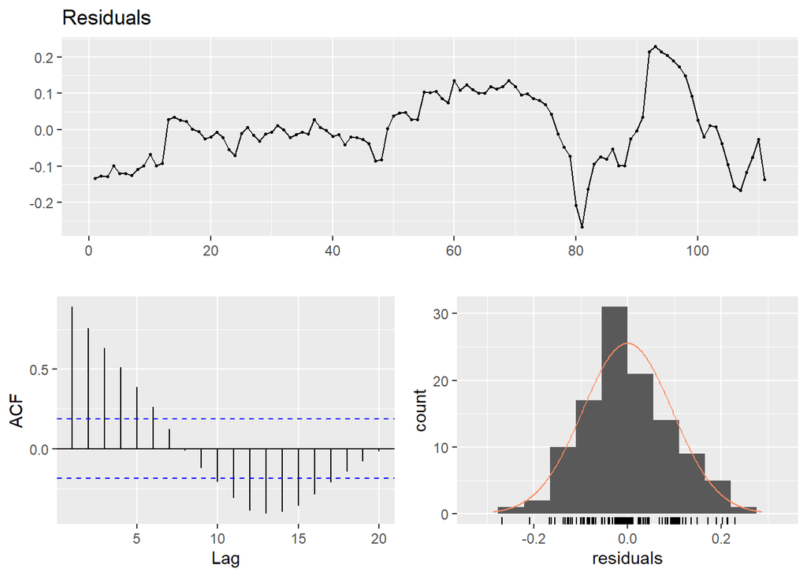

```
##
##  Breusch-Godfrey test for serial correlation of order up to 10
##
## data:  Residuals
## LM test = 94.15, df = 10, p-value = 8.019e-16
```

```r
checkresiduals(model2)
```

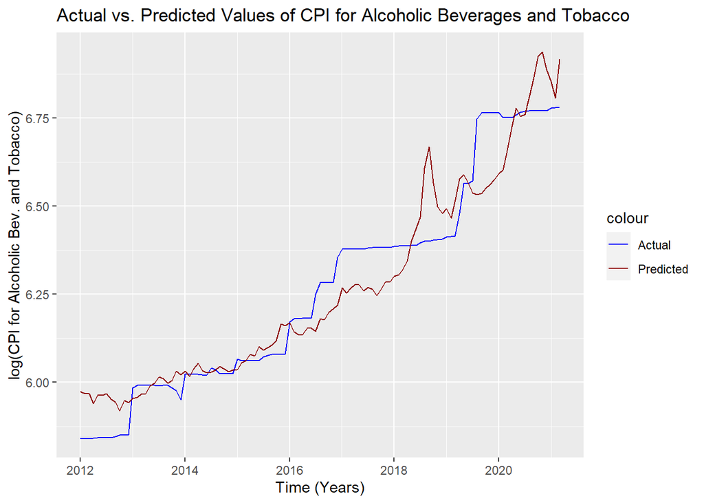

```r
data[,Fitted2:=predict(model2,data)]
cols <- c("Predicted" = "darkred", "Actual" = "blue")
ggplot(data ,aes(x=Date)) + geom_line(aes(y=CPI_ALC_TOB,color='Actual')) + geom_line(aes(y=Fitted2,color='Predicted')) + scale_color_manual(values = cols) +
labs(x = "Time (Years)", y = "log(CPI for Alcoholic Bev. and Tobacco)",
     title="Actual vs. Predicted Values of CPI for Alcoholic Beverages and Tobacco")
```

```r
model3<- lm(CPI_ALC_TOB ~ USD_TL + Int_Rate, data)
summary(model3)
```

```
##
## Call:
## lm(formula = CPI_ALC_TOB ~ USD_TL + Int_Rate, data = data)
##
## Residuals:
##       Min        1Q    Median        3Q       Max
## -0.182311 -0.063562 -0.006858  0.067632  0.206913
##
## Coefficients:
##              Estimate Std. Error t value Pr(>|t|)
## (Intercept)  5.814367   0.031487 184.659  < 2e-16 ***
## USD_TL       0.166267   0.005212  31.901  < 2e-16 ***
## Int_Rate    -0.009081   0.001852  -4.903 3.34e-06 ***
## ---
## Signif. codes:  0 '***' 0.001 '**' 0.01 '*' 0.05 '.' 0.1 ' ' 1
##
## Residual standard error: 0.08947 on 108 degrees of freedom
## Multiple R-squared:  0.9137, Adjusted R-squared:  0.9121
## F-statistic: 571.7 on 2 and 108 DF,  p-value: < 2.2e-16
```

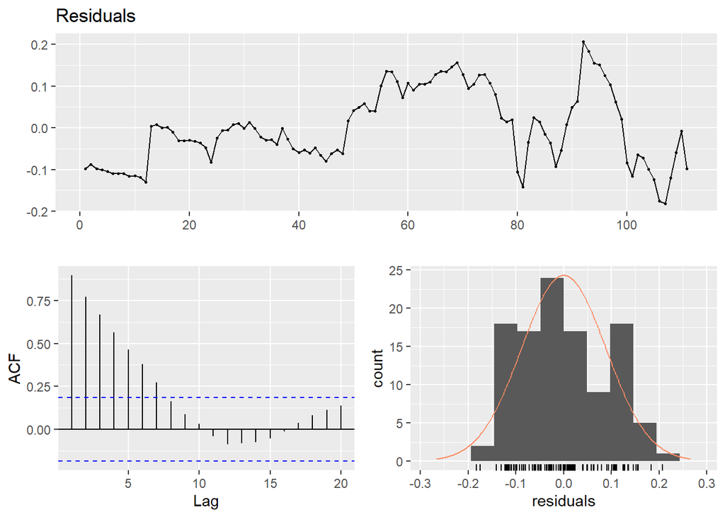

```
##
##  Breusch-Godfrey test for serial correlation of order up to 10
##
## data:  Residuals
## LM test = 93.287, df = 10, p-value = 1.191e-15
```

```r
checkresiduals(model3)
```

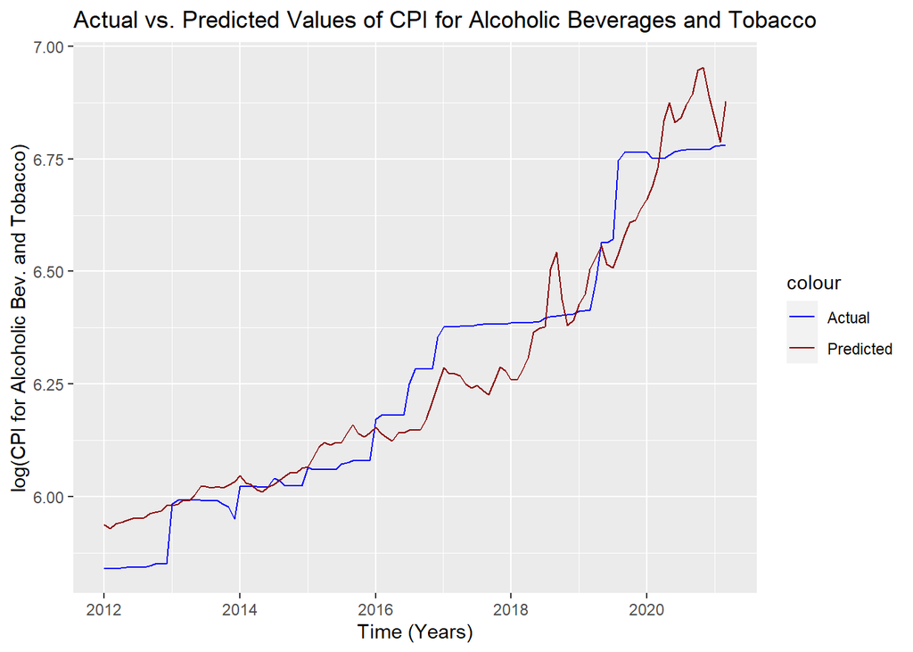

```r
data[,Fitted3:=predict(model3,data)]
cols <- c("Predicted" = "darkred", "Actual" = "blue")
ggplot(data ,aes(x=Date)) + geom_line(aes(y=CPI_ALC_TOB,color='Actual')) + geom_line(aes(y=Fitted3,color='Predicted')) + scale_color_manual(values = cols) +
labs(x = "Time (Years)", y = "log(CPI for Alcoholic Bev. and Tobacco)",
     title="Actual vs. Predicted Values of CPI for Alcoholic Beverages and Tobacco")
```

R-squared value is improved to 0.9137 all variables are significant now. Also Residual Standard Error has decreased. When we look at ACF, we see that there is autocorrelations between residuals. That’s why we should try another models to improve R-Squared value and residuals not autocorrelated.

```r
data$trend <- 1:nrow(data)
model0=lm(CPI_ALC_TOB ~ trend, data)
data[,trendvar:=predict(model0,data)]

model4=lm(CPI_ALC_TOB ~ trendvar + USD_TL + Int_Rate ,data)
summary(model4)
```

```
##
## Call:
## lm(formula = CPI_ALC_TOB ~ trendvar + USD_TL + Int_Rate, data = data)
##
## Residuals:
##       Min        1Q    Median        3Q       Max
## -0.114491 -0.035811 -0.000183  0.036115  0.171113
##
## Coefficients:
##              Estimate Std. Error t value Pr(>|t|)
## (Intercept)  1.411638   0.310295   4.549 1.43e-05 ***
## trendvar     0.770215   0.054185  14.214  < 2e-16 ***
## USD_TL       0.049325   0.008785   5.615 1.57e-07 ***
## Int_Rate    -0.008472   0.001096  -7.732 6.15e-12 ***
## ---
## Signif. codes:  0 '***' 0.001 '**' 0.01 '*' 0.05 '.' 0.1 ' ' 1
##
## Residual standard error: 0.05289 on 107 degrees of freedom
## Multiple R-squared:  0.9701, Adjusted R-squared:  0.9693
## F-statistic:  1158 on 3 and 107 DF,  p-value: < 2.2e-16
```

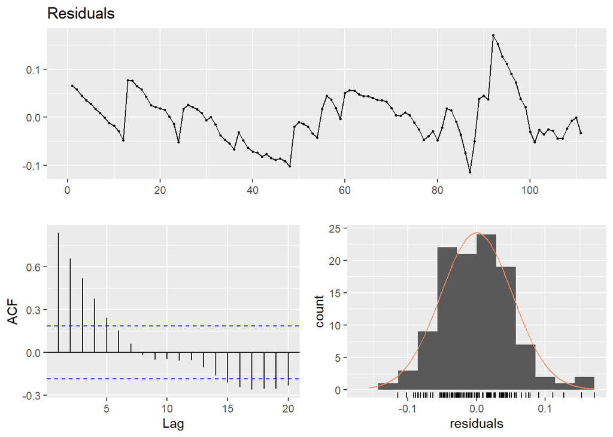

```
##
##  Breusch-Godfrey test for serial correlation of order up to 10
##
## data:  Residuals
## LM test = 80.902, df = 10, p-value = 3.341e-13
```

```r
checkresiduals(model4)
```

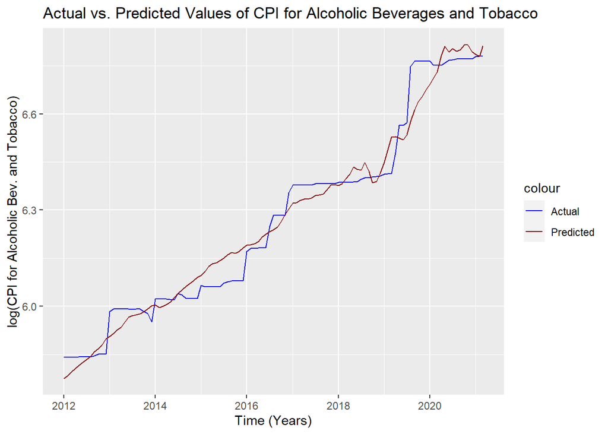

```r
data[,Fitted0:=predict(model4,data)]
cols <- c("Predicted" = "darkred", "Actual" = "blue")
ggplot(data ,aes(x=Date)) + geom_line(aes(y=CPI_ALC_TOB,color='Actual')) + geom_line(aes(y=Fitted0,color='Predicted')) + scale_color_manual(values = cols) +
labs(x = "Time (Years)", y = "log(CPI for Alcoholic Bev. and Tobacco)",
     title="Actual vs. Predicted Values of CPI for Alcoholic Beverages and Tobacco")
```

```r
data[, residuals:=residuals(model4)]
data[, Lagged:=shift(residuals(model4),1)]

finalmodel = lm(CPI_ALC_TOB ~ trendvar + USD_TL + Int_Rate + Lagged, data)
summary(finalmodel)
```

```
##
## Call:
## lm(formula = CPI_ALC_TOB ~ trendvar + USD_TL + Int_Rate + Lagged,
##     data = data)
##
## Residuals:
##       Min        1Q    Median        3Q       Max
## -0.054066 -0.014254 -0.004669  0.005442  0.137257
##
## Coefficients:
##              Estimate Std. Error t value Pr(>|t|)
## (Intercept)  1.401370   0.168069   8.338 3.16e-13 ***
## trendvar     0.769408   0.029352  26.213  < 2e-16 ***
## USD_TL       0.048563   0.004703  10.326  < 2e-16 ***
## Int_Rate    -0.007526   0.000584 -12.887  < 2e-16 ***
## Lagged       0.850308   0.051488  16.515  < 2e-16 ***
## ---
## Signif. codes:  0 '***' 0.001 '**' 0.01 '*' 0.05 '.' 0.1 ' ' 1
##
## Residual standard error: 0.02793 on 105 degrees of freedom
##   (1 observation deleted due to missingness)
## Multiple R-squared:  0.9917, Adjusted R-squared:  0.9914
## F-statistic:  3124 on 4 and 105 DF,  p-value: < 2.2e-16
```

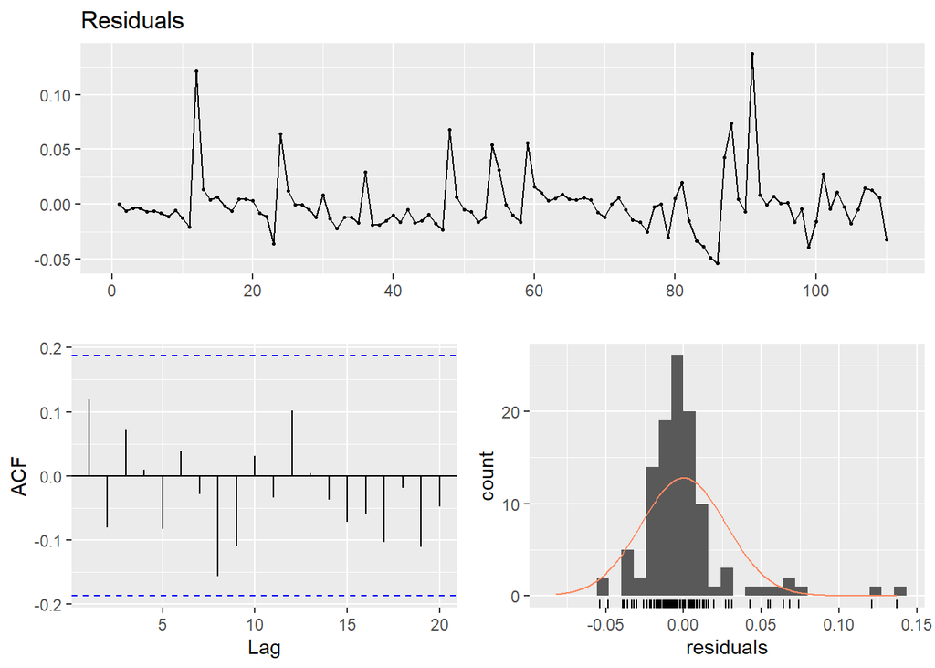

```
##
##  Breusch-Godfrey test for serial correlation of order up to 10
##
## data:  Residuals
## LM test = 7.8732, df = 10, p-value = 0.6412
```

```r
checkresiduals(finalmodel)
```

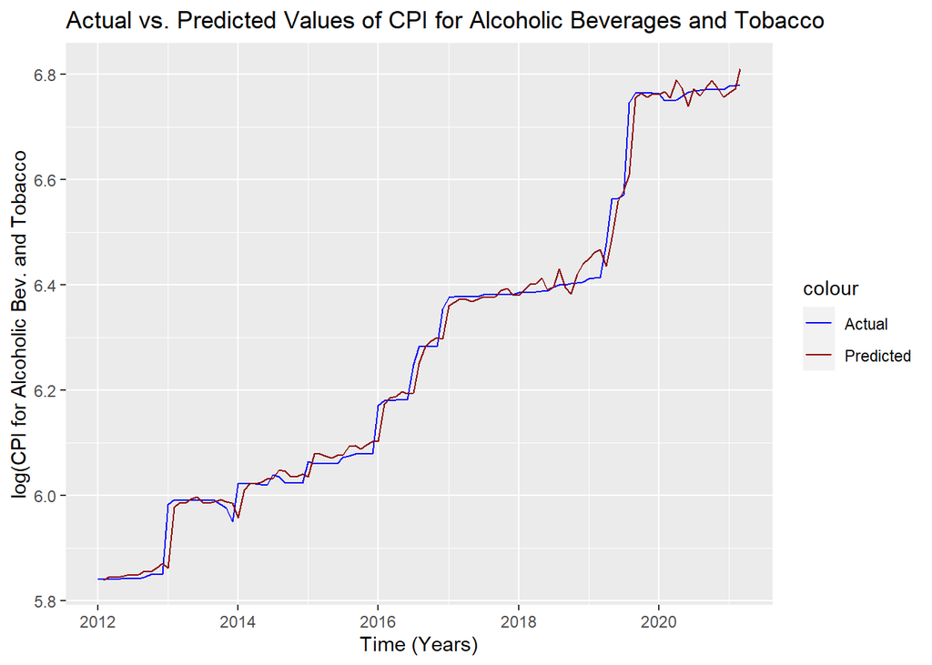

```r
data[,Fitted1:=predict(finalmodel,data)]

cols <- c("Predicted" = "darkred", "Actual" = "blue")
ggplot(data ,aes(x=Date)) + geom_line(aes(y=CPI_ALC_TOB, color='Actual')) + geom_line(aes(y=Fitted1,color='Predicted')) + scale_color_manual(values = cols) +
  labs(x = "Time (Years)", y = "log(CPI for Alcoholic Bev. and Tobacco", title="Actual vs. Predicted Values of CPI for Alcoholic Beverages and Tobacco")
```

Graph also shows that our model fitted well to our time series data. We can use this model to forecast April 2021.

## Forecasting

Forecast April 2021 value.

```r
data=rbind(data, data.table(Date = as.Date("2021-04-01")),fill=TRUE )
predict(data$Lagged)
```

```
##     Point Forecast       Lo 80      Hi 80       Lo 95      Hi 95
## 112  -0.0001837901 -0.03732325 0.03695567 -0.05698370 0.05661612
## 113  -0.0001837901 -0.05270429 0.05233671 -0.08050697 0.08013939
## 114  -0.0001837901 -0.06450693 0.06413935 -0.09855755 0.09818997
## 115  -0.0001837901 -0.07445714 0.07408956 -0.11377508 0.11340750
## 116  -0.0001837901 -0.08322350 0.08285592 -0.12718207 0.12681449
## 117  -0.0001837901 -0.09114894 0.09078136 -0.13930298 0.13893540
## 118  -0.0001837901 -0.09843714 0.09806956 -0.15044933 0.15008175
## 119  -0.0001837901 -0.10522086 0.10485328 -0.16082412 0.16045654
## 120  -0.0001837901 -0.11159227 0.11122469 -0.17056835 0.17020077
## 121  -0.0001837901 -0.11761851 0.11725093 -0.17978469 0.17941711
```

```r
data$Lagged[112]=-0.0001837901
predict(data$Int_Rate)
```

```
##     Point Forecast     Lo 80    Hi 80     Lo 95    Hi 95
## 112       22.75589 20.716283 24.79550 19.636579 25.87521
## 113       22.84662 19.411204 26.28203 17.592606 28.10063
## 114       22.91920 18.118812 27.71959 15.577640 30.26076
## 115       22.97727 16.834021 29.12051 13.581984 32.37255
## 116       23.02372 15.565442 30.48199 11.617270 34.43016
## 117       23.06088 14.319951 31.80181  9.692784 36.42897
## 118       23.09061 13.101492 33.07972  7.813574 38.36764
## 119       23.11439 11.911672 34.31711  5.981310 40.24747
## 120       23.13342 10.750484 35.51635  4.195354 42.07148
## 121       23.14864  9.616876 36.68040  2.453593 43.84369
```

```r
data$Int_Rate[112]=22.75589
predict(data$USD_TL)
```

```
##     Point Forecast    Lo 80     Hi 80    Lo 95     Hi 95
## 112       7.694781 7.307414  8.082149 7.102354  8.287208
## 113       7.749535 7.128714  8.370357 6.800071  8.699000
## 114       7.793339 6.953909  8.632769 6.509541  9.077136
## 115       7.828381 6.779014  8.877749 6.223512  9.433251
## 116       7.856416 6.604737  9.108094 5.942138  9.770693
## 117       7.878843 6.432270  9.325416 5.666500 10.091186
## 118       7.896785 6.262596  9.530974 5.397508 10.396061
## 119       7.911138 6.096402  9.725874 5.135739 10.686538
## 120       7.922621 5.934117  9.911125 4.881467 10.963775
## 121       7.931807 5.775969 10.087645 4.634737 11.228877
```

```r
data$USD_TL[112]=7.694781

data$trend <- 1:nrow(data)
model0=lm(CPI_ALC_TOB~trend,data)
data[,trendvar:=predict(model0,data)]

exp(predict(finalmodel, data[is.na(CPI_ALC_TOB) == TRUE]))
```

```
##        1
## 916.9527
```

We should not forget that we have taken the logarithm of CPI. Again we take exponential of it, and plot the graph.

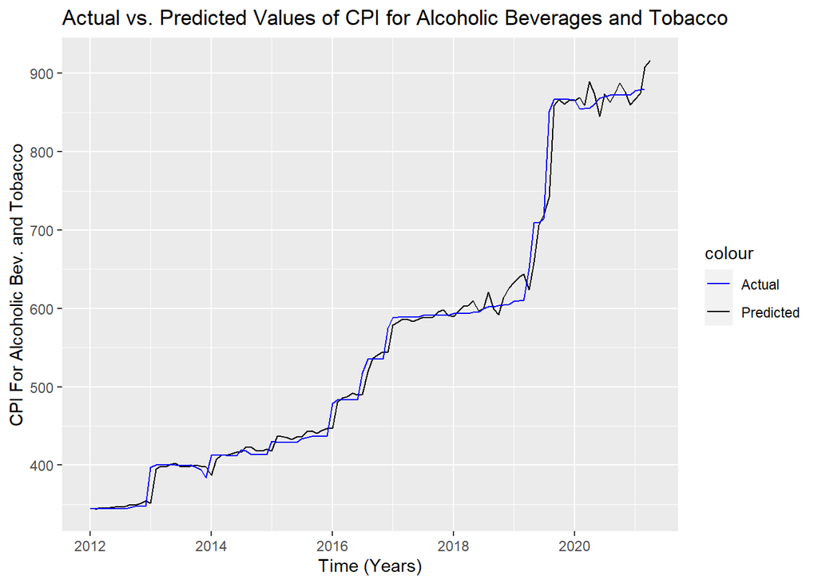

```r
data[,Fitted1:=predict(finalmodel,data)]
data$CPI_ALC_TOB <- exp(data$CPI_ALC_TOB)
data$predictnewdata <- exp(data$Fitted1)
cols <- c("Predicted" = "black", "Actual" = "blue")
ggplot() + geom_line(data = data, aes(x = Date, y = predictnewdata, color = "Predicted",)) + geom_line(data = data, aes(x = Date, y = CPI_ALC_TOB, color = "Actual")) + xlab('Time (Years)') + ylab('CPI For Alcoholic Bev. and Tobacco') + labs(title="Actual vs. Predicted Values of CPI for Alcoholic Beverages and Tobacco") + scale_color_manual(values = cols)
```

## Conclusion

This study shows that we can predict future’s CPI for Alcoholic Beverages and Tobacco using time series data for USD/TL exchange rate, interest rate paid on loans. Consumer Confidence Index did not work well constructing regression model, so we did not use it. Also 1 term lagged variable and trend variable improved our model. Residual standard error is 0.02793 which is good, our R-Squared value is 0.9917 and all regressors are significant. Residuals have approximately zero mean, constant variance and they are not autocorrelated. Using past values, we have predicted April 2021 value of CPI for Alcoholic Beverages and Tobacco which is 916.9527.

## References and Legend

[EVDS System of Central Bank of Turkey](https://evds2.tcmb.gov.tr/index.php?/evds/serieMarket)

CPI for Alcoholic Beverages and Tobacco - TP.FG.J02 02.ALKOLLÜ İÇECEKLER VE TÜTÜN-Düzey Gözlem Değeri: Orijinal Gözlem USD/TL Exchange Rate - TP.DK.USD.A.YTL (USD) ABD Doları (Döviz Alış)-Düzey Gözlem Değeri: Orijinal Gözlem Interest Rate - TP.KTF10 İhtiyaç (TL Üzerinden Açılan)(Akım Veri,%)-Düzey Gözlem Değeri: Orijinal Gözlem Consumer Confidence Index(CCI) - TP.TG2.Y01 Tüketici Güven Endeksi(*)-Düzey Gözlem Değeri: Orijinal Gözlem

Notlar  
TP.DK.USD.A.YTL Veri Kaynağı TCMB Etiketler Kurlar, Döviz, Kurları, Günlük

TP.KTF10 Veri Kaynağı TCMB [Veri Yayınlama Takvim Linki](http://www3.tcmb.gov.tr/veriyaytakvim/takvim.php) Etiketler kredi, faiz Dipnotlar Bankaların geriye dönük düzeltmeleri nedeniyle zaman serilerinde güncelleme yapılabilmektedir.

TP.FG.J02 [Uygulama Değişiklik Linki](http://www.tuik.gov.tr/PreTablo.do?alt_id=114) Veri Kaynağı TÜİK [Veri Yayınlama Takvim Linki](http://www.tuik.gov.tr/takvim/tkvim.zul#tb1) [Metaveri Linki](http://www.tuik.gov.tr/PreTablo.do?alt_id=114) [Revizyon Politika Linki](http://www.tuik.gov.tr/PreTablo.do?alt_id=114) Etiketler Tüketici, Fiyat, Endeksi, TÜFE

TP.TG2.Y01 [Uygulama Değişiklik Linki](http://www.tuik.gov.tr/PreTablo.do?alt_id=114) Veri Kaynağı TÜİK [Veri Yayınlama Takvim Linki](http://www.tuik.gov.tr/takvim/tkvim.zul#tb1) [Metaveri Linki](http://www.tuik.gov.tr/PreTablo.do?alt_id=114) [Revizyon Politika Linki](http://www.tuik.gov.tr/PreTablo.do?alt_id=114) Etiketler Tüketici, Güven, Endeksi, ve, Tüketici, Eğilim, Anketi Dipnotlar (*) Avrupa Komisyonu Ekonomik ve Finansal İşler Genel Müdürlüğü'nün tavsiyeleri doğrultusunda ve endeksin uluslararası karşılaştırılabilirliğini sağlamak amacıyla Tüketici Güven Endeksi’nin hesaplama yöntemi güncellenmiştir. [For more information](http://www.tuik.gov.tr//duyurular/duyuru_4501.pdf)